# Data Cleaning and Management (FQ23) - Week 10 Workbook

Author

Emorie D Beck

[output not shown]

# Week 10 - Review & Reflection

# Topics

1. Intro to Base R
2. `dplyr`: Manipulating Data
3. `tidyr`: Reshaping and Transforming Data
4. Codebooks
5. `purrr` & Functions
6. Review
7. Strings, dates, & regex
8. Functional Tables & Figures
9. GitHub & Parallelization
10. Today

# Lessons & Takeaways

## Lesson 1

### Always load tidyverse last

- Always load all packages **at the beginning of a script**

```r
library(psych)
library(ggdist)
library(knitr)
library(kableExtra)
library(brms)
library(broom)
library(broom.mixed)
library(patchwork)
library(plyr)
library(tidyverse)
library(furrr)
```

- Note: `tidyverse` loads: `dplyr`, `forcats` (factors), `ggplot2`, `lubrdiate`, `purrr`, `readr`, `stringr`, `tibble`, and `tidyr`
- This is good! It reduces the number of packages you have to load and ensures there’s no order issues

### Deal with Conflicts

- Use the `conflicts()` function to figure out what conflicts you have
- Use `package::fnName()` to call a function directly without loading a package / to override conflicts
  - e.g., `kableExtra` should be loaded before `tidyverse`, but then `tidyverse` masks `kableExtra::group_rows()`

```r
kable(tab) %>%
  kable_classic(html_font = "Times") %>%
  kableExtra::group_rows("Header", 1, 3)
```

## Lesson 2

### There is no single way to do anything

- The best way to do something is a way that you understand or you can introduce the mistakes you’re trying to prevent

```r
bfi %>%
  mutate(
    sid = 1:n(),
    E = rowMeans(pick(matches("E\\d")), na.rm = T),
    A = rowMeans(pick(matches("A\\d")), na.rm = T),
    C = rowMeans(pick(matches("C\\d")), na.rm = T),
    N = rowMeans(pick(matches("N\\d")), na.rm = T),
    O = rowMeans(pick(matches("O\\d")), na.rm = T)
  ) %>%
  ungroup() %>%
  select(sid, E:O)
```

|  | sid | E | A | C | N | O |
| --- | --- | --- | --- | --- | --- | --- |
| 61617 | 1 | 3.400000 | 3.400000 | 3.200000 | 2.800000 | 3.800000 |
| 61618 | 2 | 3.000000 | 3.600000 | 4.000000 | 3.800000 | 3.200000 |
| 61620 | 3 | 3.800000 | 4.400000 | 4.000000 | 3.600000 | 3.600000 |
| 61621 | 4 | 4.000000 | 4.800000 | 4.200000 | 2.800000 | 3.600000 |
| 61622 | 5 | 3.600000 | 3.400000 | 3.600000 | 3.200000 | 3.200000 |
| 61623 | 6 | 4.000000 | 5.600000 | 4.400000 | 3.000000 | 3.800000 |
| 61624 | 7 | 4.200000 | 4.000000 | 3.600000 | 1.400000 | 3.800000 |
| 61629 | 8 | 3.200000 | 2.800000 | 3.000000 | 4.200000 | 3.400000 |
| 61630 | 9 | 3.750000 | 3.800000 | 4.800000 | 3.600000 | 5.000000 |
| 61633 | 10 | 3.600000 | 4.800000 | 4.000000 | 4.200000 | 3.600000 |

[output cut: 2790 more lines]

```r
bfi %>%
  mutate(sid = 1:n()) %>%
  pivot_longer(
    cols = c(-sid, -gender, -education, -age)
    , names_to = c("trait", "item")
    , names_sep = -1
    , values_to = "value"
  ) %>%
  group_by(sid, trait) %>%
  summarize(value = mean(value, na.rm = T)) %>%
  pivot_wider(names_from = "trait", values_from = "value") %>%
  ungroup()
```

| sid | A | C | E | N | O |
| --- | --- | --- | --- | --- | --- |
| 1 | 3.400000 | 3.200000 | 3.400000 | 2.800000 | 3.800000 |
| 2 | 3.600000 | 4.000000 | 3.000000 | 3.800000 | 3.200000 |
| 3 | 4.400000 | 4.000000 | 3.800000 | 3.600000 | 3.600000 |
| 4 | 4.800000 | 4.200000 | 4.000000 | 2.800000 | 3.600000 |
| 5 | 3.400000 | 3.600000 | 3.600000 | 3.200000 | 3.200000 |
| 6 | 5.600000 | 4.400000 | 4.000000 | 3.000000 | 3.800000 |
| 7 | 4.000000 | 3.600000 | 4.200000 | 1.400000 | 3.800000 |
| 8 | 2.800000 | 3.000000 | 3.200000 | 4.200000 | 3.400000 |
| 9 | 3.800000 | 4.800000 | 3.750000 | 3.600000 | 5.000000 |
| 10 | 4.800000 | 4.000000 | 3.600000 | 4.200000 | 3.600000 |

[output cut: 2790 more lines]

## Lesson 3

### Start at the end

- What do you want your data to look like?
- What do they look like now?
- Now fill in the middle

HLM / MLM / MEM: RE ex: time, trial, stimuli, group, study, day, w/in person conditions FE ex: gender, baseline age, b/w subject conditions, country, etc. (can also be an RE)

ID | RE1 | RE2 | DV | FE1  
1 | 1 | 1 | 4 | 3  
1 | 1 | 2 | 3 | 3  
1 | 2 | 1 | 2 | 3  
1 | 2 | 2 | 1 | 3  
2 | 1 | 1 | 5 | 1  
2 | 1 | 2 | 3 | 1  
2 | 2 | 1 | 1 | 1  
2 | 2 | 2 | 2 | 1

### Start at the end

- `pivot_longer()`: RE_1_1:RE_2_2
  - names_to = c(“RE1”, “RE2”)
  - values_to = “DV”
  - names_sep = “_”
  - names_prefix = “RE_”
- Note this is only possible / easy because of the naming scheme! If we had them named “RE1_1”, this would not have been possible / would have been CONSIDERABLY more difficult

## Lesson 4

### Don’t be afraid to split your data into chunks

- In alignment with starting at the end, a key strategy is knowing how you can **chunk** your data
- No right or wrong way to chunk, but some examples are:
  - items / values from the same scale / task (e.g., DV across trials / conditions)
  - baseline items (from other survey or from baseline wave)
  - outcome variables
  - descriptive variables
  - item-level variables v. composites

## Lesson 5

### Joining data requires a key, so be thoughtful and you’ll always be able to put the pieces together

- The most important thing when splitting data into chunks is to make sure you can put it back together
- This requires one (e.g., participant ID) or more (e.g., participant ID, wave) keys that allows R to match the right values together
- This should be the last thing you do
  - Please don’t create mega datasets where you tack things on to the raw data as you go
  - This will eat RAM and make your life harder (and sometimes could end up in you accidentally sharing identifying information!!)

## Lesson 6

### One of the most important skills is getting comfortable making data move flexibly from wide to long

- Remember our example above? Without knowledge of how to do so, it would have been almost impossible
- It’s okay if it takes more than one step! That’s better than manually moving stuff in excel and not creating a reproducible path!

```r
bfi %>%
  mutate(sid = 1:n()) %>%
  pivot_longer(
    cols = c(-sid, -gender, -education, -age)
    , names_to = c("trait", "item")
    , names_sep = -1
    , values_to = "value"
  ) %>%
  group_by(sid, trait) %>%
  summarize(value = mean(value, na.rm = T)) %>%
  pivot_wider(names_from = "trait", values_from = "value") %>%
  ungroup()
```

| sid | A | C | E | N | O |
| --- | --- | --- | --- | --- | --- |
| 1 | 3.400000 | 3.200000 | 3.400000 | 2.800000 | 3.800000 |
| 2 | 3.600000 | 4.000000 | 3.000000 | 3.800000 | 3.200000 |
| 3 | 4.400000 | 4.000000 | 3.800000 | 3.600000 | 3.600000 |
| 4 | 4.800000 | 4.200000 | 4.000000 | 2.800000 | 3.600000 |
| 5 | 3.400000 | 3.600000 | 3.600000 | 3.200000 | 3.200000 |
| 6 | 5.600000 | 4.400000 | 4.000000 | 3.000000 | 3.800000 |
| 7 | 4.000000 | 3.600000 | 4.200000 | 1.400000 | 3.800000 |
| 8 | 2.800000 | 3.000000 | 3.200000 | 4.200000 | 3.400000 |
| 9 | 3.800000 | 4.800000 | 3.750000 | 3.600000 | 5.000000 |
| 10 | 4.800000 | 4.000000 | 3.600000 | 4.200000 | 3.600000 |

[output cut: 2790 more lines]

## Lesson 7

### Establish a consistent naming scheme

- label objects relative to a stage or research question
  - e.g., `nested_RQ1`, `RQ1_mods`, `raw_df`
  - this will help you clear your environment of clutter
- use temporary objects repeatedly
  - e.g., if you need to use an object as an intermediary step, call it `tmp` and overwrite it as many times as is useful
  - You can always remove it using `rm(tmp)`

## Lesson 8

### You won’t remember details about raw variables or variables you create, document them

- Clearly document your raw data and planned transformations before (preregistration) or as (deviations or just reactive responses to aspects of the data) you clean your data
- Clearly document all new variables you create, including their scale, etc.

## Lesson 9

### Reference data frames are great keys for ordering and renaming

- Clearly documenting all new variables you create also creates the opportunity to create **reference data frames**, which can include variable names in the data, category information, longer names for the variables, descriptions of the scales, and the link function / column names e.g.,

### Reference data frames are great keys for ordering and renaming

```r
out <- tribble(
  ~cat,     ~name,        ~scale,      ~long_name,              ~lab,
"Outcome",  "dementia",   "0/1",       "Clinical Dementia",      "OR [CI]",
"Outcome",  "braak",      "1-5",       "Braak Stage",            "est. [CI]"
)

tab %>%
  left_join(out %>% select(outcome = name, long_out = long_name, lab))
```

## Lesson 10

### Reorder everything using factors

- Often, there are specific orders we want / need strings to be in; this is where factors come in
- There’s a whole package for this called [`forcats`](https://forcats.tidyverse.org).
- Reference data frames are a great way to order your variables

```r
out <- tribble(
  ~cat,     ~name,        ~scale,      ~long_name,              ~lab,
"Outcome",  "dementia",   "0/1",       "Clinical Dementia",      "OR [CI]",
"Outcome",  "braak",      "1-5",       "Braak Stage",            "est. [CI]"
)

tab %>%
  left_join(out %>% select(outcome = name, long_out = long_name, lab)) %>%
  mutate(long_out = factor(long_out, levels = out$long_name))
# mutate(long_out = factor(oucome, levels = out$name, labels = out$long_name))
```

### Reorder everything using factors

- Remember this?

```r
terms <- tribble(
  ~path,     ~new,                         ~level
  "i~1",     "Intercept",                  "Fixed",
  "s~1",     "Slope",                      "Fixed",
  "i~~i",    "Intercept Variance",         "Random",
  "s~~s",    "Slope Variance",             "Random",
  "i~~s",    "Intercept-Slope Covariance", "Random"
)

extract_fun <- function(m, trait){
  p <- parameterEstimates(m) %>%
    data.frame()
  # saveRDS(p, file = sprintf("results/summary/%s.RDS", trait))
  p %>%
    unite(path, lhs, op, rhs, sep = "") %>%
    filter(path %in% terms$path) %>%
    left_join(terms) %>%
    select(term = new, est, ci.lower, ci.upper, pvalue) %>%
    mutate(term = factor(term, levels = terms$new)) %>%
    arrange(term)
}
```

## Lesson 11

### Long lists of anything are asking for trouble

- It took me way too long to even make the short examples above using `tribble()`
- Using a spreadsheet is an easier way to compile that information
- The `googlesheets4` package is also a package dedicated to helping you to read, write, and parse Google Sheets
- It’s easy to load files stored on GitHub
- Spreadsheets are user friendly even for those who aren’t code literate
- It’s way easier to reorder a spreadsheet (cut-insert cut rows) than to have to move rows around in an R script
- f%#*ing commas and quotes

## Lesson 12

### File structure and organization are your most important data cleaning & management tools

- Your data will never be clean if you don’t know where your files are!
- No one wants to have to rerun things repeatedly
  - Store large files (models, bootstrapped resamples, bayesian samples, etc.) using a clear, machine readable, parseable file structure (e.g., `dementia-E-age-unadj.RDS`)
  - These can then be read in like:

```r
nested_res <- tibble(
  file = list.files("models"),
  mod = map(file, \(x) readRDS(sprintf("models/%s", x)))
  ) %>%
  separate(file, c("outcome", "trait", "moderator", "adj"), sep = "-")
```

### File structure and organization are your most important data cleaning & management tools

- Same thing goes for smaller objects
- Save those small ones, like summaries (e.g., from `broom::tidy()`, `coef()`, etc.), predicted values, random effects, etc. using the same file structure, and you always have everything at your fingertips
- Plus you can merge them more easily!
- This organization also transfers to GitHub for easy loading via raw links!

## Lesson 13

### Some things / functions are portable across projects, some need modification

- Some functions are portable:

```r
z_scale <- function(x) (x - mean(x, na.rm = T))/sd(x, na.rm = T)
pomp_score <- function(x){
  rng <- range(x, na.rm = T)
  (x - rng[1])/(rng[2] - rng[1])*100
}
```

### Some things / functions are portable across projects, some need modification

- Some are not:
- This function works for `lavaan`. With slight modifications, it could also work for `broom::tidy()` output

```r
format_fun <- function(d){
  d %>%
    mutate(sig = ifelse(pvalue < .05, "sig", "ns")) %>%
    rowwise() %>%
    mutate_at(vars(est, ci.lower, ci.upper), round_fun) %>%
    mutate_at(vars(pvalue), pround_fun) %>%
    ungroup() %>%
    mutate(CI = sprintf("[%s,%s]", ci.lower, ci.upper)) %>%
    mutate_at(vars(est, CI, pvalue), ~ifelse(sig == "sig" & !is.na(sig), sprintf("<strong>%s</strong>", .), .))
}
```

### Some things / functions are portable across projects, some need modification

- One possibility is to create an `.R` script that you can “source” (`source("custom_functions.R")`)
  - You could have general functions (e.g., `z_scale()`, `pomp_score()`) and use case specific ones (e.g., `lavaan_format_fun()` or `broom_format_fun()`)
  - I often like to copy these into my R workflow because it means that everything is included in the scripts (even though the `.R` script can be included in the repo)

## Lesson 14

### Resources are finite, so be aware of how you’re using them

- Using grid view in your Environment tab is a great way to track resources
- The environment below came after running 95 separate models, all of which were held in memory

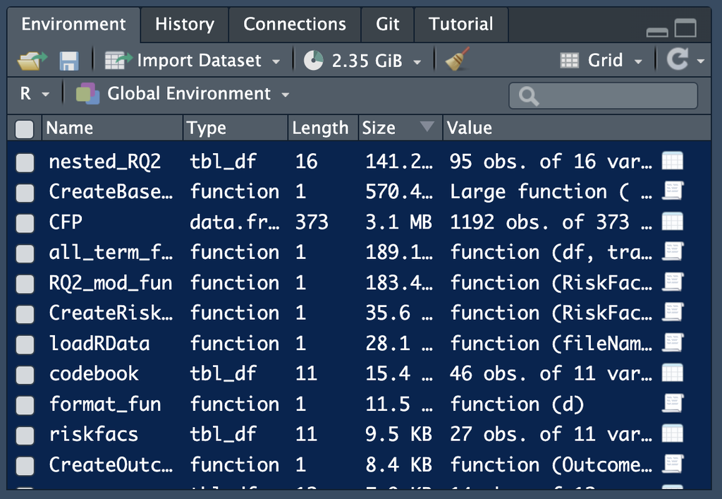

### Resources are finite, so be aware of how you’re using them

- Using grid view in your Environment tab is a great way to track resources
- The environment below came from reloading smaller summary objects rather than keeping all the models in working memory

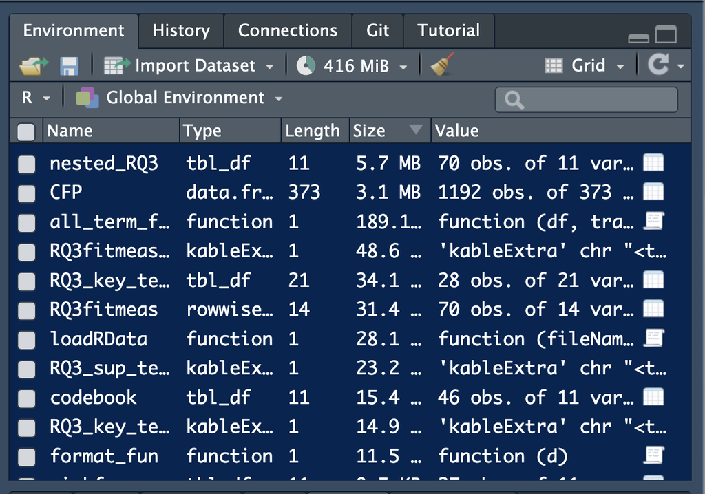

### Resources are finite, so be aware of how you’re using them

- Activity Monitor (Mac) or Process Monitor (Windows) is another great way to track general system usage across many programs, not just `R`
- I use this in particular when I’m doing parallelization
  - Sometimes threads stall (drop to 0% CPU or Memory)
  - Sometimes threads use way too much memory (and you start using swap)
  - It’s great to track this so you can interrupt

## Lesson 15

### Data frames are your friend

- They are the easiest objects to work with in R because of the number of dedicated tools and functions for working with them
- But they can get unwieldy (e.g., printing a data frame with hundreds of columns and thousands of rows)
- `tibbles` help with this but don’t always play nice
  - You can’t go from some classes to tibble directly
  - Instead go data.frame -> tibble

```r
r <- cor(df, use = "pairwise")
r[upper.tri(r, diag = T)] <- NA
r %>%
  data.frame() %>%
  as_tibble()
```

## Lesson 16

### RStudio / Pivot Cheat Sheets

[figure not shown]

Posit Cheatsheets

### RStudio / Pivot Cheat Sheets

- [Quarto](https://rstudio.github.io/cheatsheets/quarto.pdf)
- [RStudio](https://rstudio.github.io/cheatsheets/rstudio-ide.pdf)
- [RMarkdown](https://rstudio.github.io/cheatsheets/rmarkdown.pdf)
- [lubridate](https://rstudio.github.io/cheatsheets/lubridate.pdf)
- [stringr](https://rstudio.github.io/cheatsheets/strings.pdf)
- [purrr](https://rstudio.github.io/cheatsheets/purrr.pdf)
- [readr](https://rstudio.github.io/cheatsheets/data-import.pdf)
- [tidyr](https://rstudio.github.io/cheatsheets/tidyr.pdf)
- [dplyr](https://rstudio.github.io/cheatsheets/data-transformation.pdf)
- [ggplot2](https://rstudio.github.io/cheatsheets/data-visualization.pdf)

## Hacks

- [The option / alt key and other shortcuts](https://support.posit.co/hc/en-us/articles/200711853-Keyboard-Shortcuts-in-the-RStudio-IDE)
- The tab key: “attempt completion”
- [R templates](https://quarto.org/docs/extensions/starter-templates.html)
- [GitHub Pages](https://pages.github.com)
- [Functions without inputs](https://bookdown.org/rdpeng/rprogdatascience/functions.html)